# EDA_Proyecto_Final

```r
library(tidyverse)
```

# Análisis exploratorio

Importar y visualizar dataset

```r
df <- read.csv('churn_prediction_features.csv')
str(df)
```

```
## 'data.frame':    5293 obs. of  112 variables:
##  $ order_count_3m                                                 : int  1 1 1 1 1 1 1 1 1 1 ...
##  $ order_count_historic                                           : int  1 1 1 1 1 1 1 1 1 1 ...
##  $ distinct_sku_3m                                                : int  8 5 4 11 6 7 17 4 7 3 ...
##  $ distinct_sku_historic                                          : int  8 5 4 11 6 7 17 4 7 3 ...
##  $ gmv_3m                                                         : num  150360 112770 145272 201431 161276 ...
##  $ gmv_historic                                                   : num  150360 112770 145272 201431 161276 ...
##  $ unique_vendors_last_3m                                         : int  1 1 1 7 6 7 10 1 1 1 ...
##  $ unique_vendors_historic                                        : int  1 1 1 7 6 7 10 1 1 1 ...
##  $ AOV_3m                                                         : num  150360 112770 145272 201431 161276 ...
##  $ AOV_historic                                                   : num  150360 112770 145272 201431 161276 ...
##  $ antiquity_days                                                 : int  0 0 0 0 0 0 0 0 0 0 ...
##  $ visits_count_3m                                                : int  0 0 0 0 0 0 0 0 0 0 ...
##  $ canceled_orders                                                : int  0 0 0 0 0 0 0 0 0 0 ...
##  $ tickets_finales                                                : int  0 0 0 0 0 0 0 0 0 0 ...
```

[output cut: 86 more lines]

## Determinar cuáles columnas son numéricas o categóricas

### Variables categóricas

Utilizando expresiones regulares, se buscan columnas cuyo nombre empiece por “sub_categoria_” & “warehouse_”, posteriormente se agregan otras columnas que corresponden a variables categóricas

```r
categorical_cols <- names(df)[grepl("^sub_categoria_|^warehouse_", names(df))]
categorical_cols <- c(categorical_cols, 'customer_id', 'has_churned_before', 'is_churned')
```

### Variables numéricas

Se toman las columnas del dataframe ‘df’ que no están en el vector de columnas categóricas

```r
numerical_cols <- setdiff(names(df), categorical_cols)
```

## Reducción de dimensionalidad

### Reducción de Variables categóricas

Se verifica entonces la dimensión del dataframe de variables categóricas, eliminando la columna customer_id

```r
df_categoricals = subset(df, select = categorical_cols)
df_categoricals <- df_categoricals[, !(names(df_categoricals) %in% c("customer_id"))]

df_categoricals <- df_categoricals[-c(4168, 4713), ]

dim(df_categoricals)
```

```
## [1] 5291   83
```

En total hay 83 columnas categóricas. Se realizarán pruebas de independecia en estas 83 columnas categóricas.

### Verificando supuestos de la prueba chi cuadrado

Uno de los supuestos indica que debe haber almenos cinco ocurrencias de cada clase para cada variable categórica. Se verificará que cada variable categórica cumpla con este supuesto.

```r
# Inicializa un dataframe para almacenar los resultados
resultados <- data.frame(column_name = character(), negative_class = integer(), positive_class = integer())

# Calcula los conteos para cada columna
for (column_name in names(df_categoricals)) {
  positive_count <- sum(df_categoricals[[column_name]] == 1)
  negative_count <- sum(df_categoricals[[column_name]] == 0)

  # Añade los resultados al dataframe
  resultados <- rbind(resultados, data.frame(column_name, negative_class = negative_count, positive_class = positive_count))
}

library(knitr)
kable(head(resultados), caption = "Conteo de classes por variable")
```

Conteo de classes por variable

| column_name | negative_class | positive_class |
| --- | --- | --- |
| sub_categoria_Accesorios | 5111 | 180 |
| sub_categoria_Acondicionador | 4434 | 857 |
| sub_categoria_Ambientadores | 5271 | 20 |
| sub_categoria_Analgésicos | 4646 | 645 |
| sub_categoria_Antibióticos.y.analgésicos | 5012 | 279 |
| sub_categoria_Anticonceptivos | 2514 | 2777 |

Determinar categorías con menos de 5 registros en la clase negativa:

```r
resultados %>% filter(negative_class < 5)
```

```
## [1] column_name    negative_class positive_class
## <0 rows> (or 0-length row.names)
```

Determinar categorías con menos de 5 registros en la clase positiva:

```r
resultados %>% filter(positive_class < 5)
```

```
##                           column_name negative_class positive_class
## 1 sub_categoria_Detergentes.y.jabones           5290              1
```

En la clase negativa no resultó ninguna categoría, pero en la positiva se tiene “sub_categoria_Detergentes y jabones”. Se procederá a excluir esta categoría de la prueba.

```r
df_categoricals <- df_categoricals[, !(names(df_categoricals) %in% c("sub_categoria_Detergentes.y.jabones"))]
```

### Aplicar prueba chi cuadrado

Se procede a hacer pruebas chi cuadrado entre todas las posibles combinaciones de columnas categóricas que quedaron, y se guarda este resultado en un nuevo dataframe.

Esta prueba es útil para evaluar la independencia estadística entre pares de variables categóricas en un conjunto de datos.

Ahora incia un proceso de selección de variables categóricas basado en la independencia estadística. Se empienzan a descartar todas las que son dependientes.

Se incia el proceso con todas aquellas que son dependientes a warehouse_Bogota (escogida aleatoriamente entre todas las variables)

```r
library(dplyr)

p_values <- numeric(length = ncol(df_categoricals) - 1)
names(p_values) <- setdiff(colnames(df_categoricals), "warehouse_Bogota")

# Realizar las pruebas de chi-cuadrado
for (col in names(p_values)) {
  # Crear la tabla de contingencia para cada columna con 'warehouse_Bogota'
  contingency_table <- table(df_categoricals$warehouse_Bogota, df_categoricals[[col]])

  # Realizar la prueba chi-cuadrado y almacenar el valor p
  test_result <- chisq.test(contingency_table)
  p_values[col] <- test_result$p.value
}

# Ahora, filtramos los nombres de las columnas con un valor p menor a 0.05
significant_columns <- names(p_values)[p_values > 0.05]
significant_columns <- significant_columns[!is.na(significant_columns)]
significant_columns <- c(significant_columns, "warehouse_Bogota")

significant_columns
```

```
##  [1] "sub_categoria_Acondicionador"
##  [2] "sub_categoria_Ambientadores"
##  [3] "sub_categoria_Anticonceptivos"
##  [4] "sub_categoria_Complementos.y.vitaminas"
##  [5] "sub_categoria_Cuidado.corporal"
##  [6] "sub_categoria_Cuidado.de.los.pies"
##  [7] "sub_categoria_Cuidado.facial"
##  [8] "sub_categoria_Gomas"
##  [9] "sub_categoria_Naturales"
## [10] "sub_categoria_Productos.para.rehabilitación"
## [11] "sub_categoria_Proteccion.e.higiene.íntima.femenina"
## [12] "warehouse_Bogota"
```

```r
df_independent_variables <- subset(df_categoricals, select = significant_columns)
```

El resultado evidencia que 12 columnas son independientes a la columna warehouse_Bogota. Se procederá a utilizar otra columna aleatoria para verificar nuevamente independecia y descartar las dependientes.

Para este proceso se repite la prueba de chi-cuadrado

Se toma la variable ‘sub_categoria_Ambientadores’, se eliminan las que son dependientes a esta y se repite el proceso hasta que todas las variables categóricas restantes, sean independientes

```r
p_values <- numeric(length = ncol(df_independent_variables) - 1)
names(p_values) <- setdiff(colnames(df_independent_variables), "sub_categoria_Ambientadores")

# Realizar las pruebas de chi-cuadrado
for (col in names(p_values)) {
  # Crear la tabla de contingencia para cada columna con 'sub_categoria_Ambientadores'
  contingency_table <- table(df_independent_variables$sub_categoria_Ambientadores, df_independent_variables[[col]])

  # Realizar la prueba chi-cuadrado y almacenar el valor p
  test_result <- chisq.test(contingency_table)
  p_values[col] <- test_result$p.value
}

# Ahora, filtramos los nombres de las columnas con un valor p menor a 0.05
significant_columns <- names(p_values)[p_values > 0.05]
significant_columns <- significant_columns[!is.na(significant_columns)]
significant_columns <- c(significant_columns, "sub_categoria_Ambientadores")

significant_columns
```

```
## [1] "sub_categoria_Complementos.y.vitaminas"
## [2] "sub_categoria_Productos.para.rehabilitación"
## [3] "warehouse_Bogota"
## [4] "sub_categoria_Ambientadores"
```

```r
df_independent_variables <- subset(df_independent_variables, select = significant_columns)
```

Después de reptir el proceso, quedan 4 variables. Se procederá a repetir con la sub categoria Complementos y vitaminas

```r
p_values <- numeric(length = ncol(df_independent_variables) - 1)
names(p_values) <- setdiff(colnames(df_independent_variables), "sub_categoria_Complementos.y.vitaminas")

# Realizar las pruebas de chi-cuadrado
for (col in names(p_values)) {
  # Crear la tabla de contingencia para cada columna con 'sub_categoria_Complementos.y.vitaminas'
  contingency_table <- table(df_independent_variables$sub_categoria_Complementos.y.vitaminas, df_independent_variables[[col]])

  # Realizar la prueba chi-cuadrado y almacenar el valor p
  test_result <- chisq.test(contingency_table)
  p_values[col] <- test_result$p.value
}

# Ahora, filtramos los nombres de las columnas con un valor p menor a 0.05
significant_columns <- names(p_values)[p_values > 0.05]
significant_columns <- significant_columns[!is.na(significant_columns)]
significant_columns <- c(significant_columns, "sub_categoria_Complementos.y.vitaminas")

significant_columns
```

```
## [1] "warehouse_Bogota"
## [2] "sub_categoria_Ambientadores"
## [3] "sub_categoria_Complementos.y.vitaminas"
```

```r
df_independent_variables <- subset(df_independent_variables, select = significant_columns)
```

En este ultimo caso las tres variables restantes son indpendientes. Ahora se procede a utilizar estas 3 variables para el modelo.

## Variables Numéricas

Para las variables numéricas se realiza una matrix de correlación

```r
library(reshape2)
```

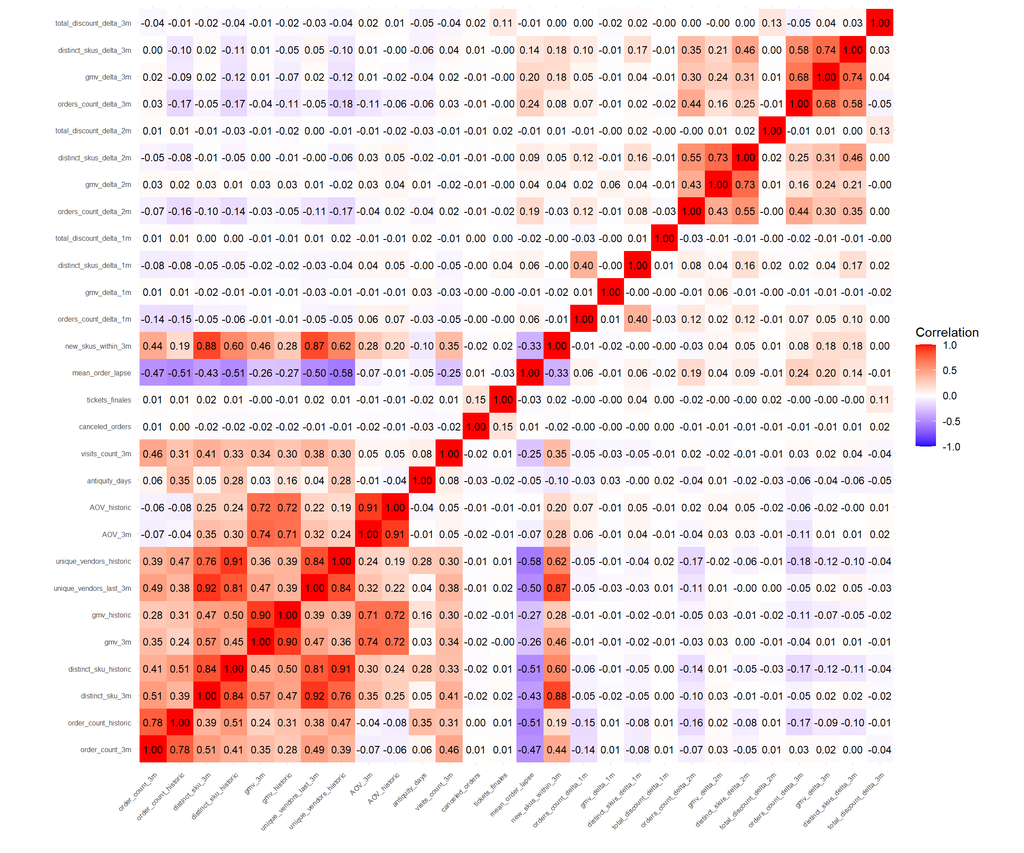

```r
cor_matrix <- cor(df[numerical_cols], use = "complete.obs")

# Transforma la matriz de correlación para la visualización
cor_melted <- melt(cor_matrix)

# Configura el tamaño de la fuente para los labels (ajusta según sea necesario)
font_size <- 6

ggplot(data = cor_melted, aes(x = Var1, y = Var2, fill = value)) +
  geom_tile() +
  scale_fill_gradient2(low = "blue", high = "red", mid = "white",
                       midpoint = 0, limit = c(-1, 1), space = "Lab",
                       name="Correlation") +
  theme_minimal() +
  theme(axis.text.x = element_text(angle = 45, vjust = 1, hjust=1, size = font_size),
        axis.text.y = element_text(size = font_size)) +
  coord_fixed() +
  labs(x = '', y = '') +
  geom_text(aes(label = sprintf("%.2f", value)), size = 3, check_overlap = TRUE)
```

Se evidencia que existen variables con correlaciones altas. Estas se eliminarán con el Variance Inflation Factor.

Antes de este proceso, se deben revisar los datos faltantes.

### Datos faltantes

```r
columns_for_reduction = c(numerical_cols, significant_columns, 'is_churned')

df_reduction = subset(df, select = columns_for_reduction)

dim(df_reduction)
```

```
## [1] 5293   32
```

Se evidencia la presencia de valores faltantes en el dataframe. Se procederá a visualizarlos.

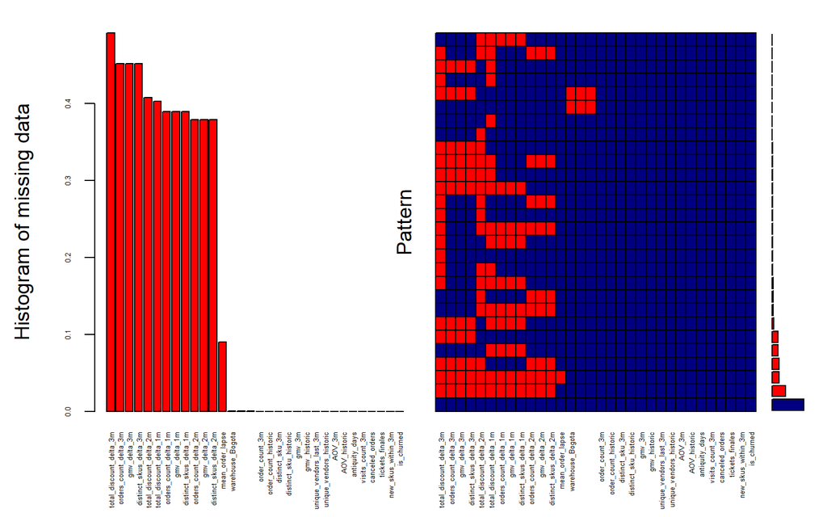

```
##
##  Variables sorted by number of missings:
##                                Variable        Count
##                 total_discount_delta_3m 0.4917815983
##                   orders_count_delta_3m 0.4519176271
##                            gmv_delta_3m 0.4519176271
##                  distinct_skus_delta_3m 0.4519176271
##                 total_discount_delta_2m 0.4077082940
##                 total_discount_delta_1m 0.4029850746
##                   orders_count_delta_1m 0.3893822029
##                            gmv_delta_1m 0.3893822029
##                  distinct_skus_delta_1m 0.3893822029
##                   orders_count_delta_2m 0.3793689779
##                            gmv_delta_2m 0.3793689779
##                  distinct_skus_delta_2m 0.3793689779
##                        mean_order_lapse 0.0897411676
##                        warehouse_Bogota 0.0003778575
##             sub_categoria_Ambientadores 0.0003778575
##  sub_categoria_Complementos.y.vitaminas 0.0003778575
##                          order_count_3m 0.0000000000
##                    order_count_historic 0.0000000000
##                         distinct_sku_3m 0.0000000000
##                   distinct_sku_historic 0.0000000000
##                                  gmv_3m 0.0000000000
##                            gmv_historic 0.0000000000
##                  unique_vendors_last_3m 0.0000000000
##                 unique_vendors_historic 0.0000000000
##                                  AOV_3m 0.0000000000
##                            AOV_historic 0.0000000000
##                          antiquity_days 0.0000000000
##                         visits_count_3m 0.0000000000
##                         canceled_orders 0.0000000000
##                         tickets_finales 0.0000000000
##                      new_skus_within_3m 0.0000000000
##                              is_churned 0.0000000000
```

```r
library(VIM)
aggr_plot <- aggr(df_reduction, col=c('navyblue', 'red'), numbers=FALSE, sortVars=TRUE,
                  cex.axis=0.4, gap=1, ylab=c("Histogram of missing data", "Pattern"))
```

Se remueven aquellas columnas que tienen 40% o más de valores faltantes:

```r
porcentaje_nulos <- sapply(df_reduction, function(x) mean(is.na(x))) * 100
df_filtrado <- df_reduction[, porcentaje_nulos < 40]
```

```r
names(df_filtrado)
```

```
##  [1] "order_count_3m"
##  [2] "order_count_historic"
##  [3] "distinct_sku_3m"
##  [4] "distinct_sku_historic"
##  [5] "gmv_3m"
##  [6] "gmv_historic"
##  [7] "unique_vendors_last_3m"
##  [8] "unique_vendors_historic"
##  [9] "AOV_3m"
## [10] "AOV_historic"
## [11] "antiquity_days"
## [12] "visits_count_3m"
## [13] "canceled_orders"
## [14] "tickets_finales"
## [15] "mean_order_lapse"
## [16] "new_skus_within_3m"
## [17] "orders_count_delta_1m"
## [18] "gmv_delta_1m"
## [19] "distinct_skus_delta_1m"
## [20] "orders_count_delta_2m"
## [21] "gmv_delta_2m"
## [22] "distinct_skus_delta_2m"
## [23] "warehouse_Bogota"
## [24] "sub_categoria_Ambientadores"
## [25] "sub_categoria_Complementos.y.vitaminas"
## [26] "is_churned"
```

#### Eliminar multicolinealidad con Variance Inflation Factor (VIF)

Recordemos que:

- Un VIF ≥ 5 indica alta multicolinealidad entre la correspondiente variable independiente y las demás variables.
- Recomendación: Eliminar una columna a la vez. Aquella con el máximo VIF ≥ 5. Luego, para el nuevo dataframe, calcular nuevamente VIF e identificar nuevas columnas con VIF ≥ 5 máximo, y así sucesivamente hasta obtener solo valores de VIF < 5.
- Según corresponda, variables categóricas deben previamente codificarse usando por ejemplo OneHotEncoder().

```r
library(car)

modelo <- lm(is_churned ~ ., data = df_filtrado)

# Calcular VIF
vif_valores <- vif(modelo)

# Crear un dataframe para mostrar los nombres de las variables y sus VIFs
vif_df <- data.frame(VIF = vif_valores)

# Imprimir el dataframe
kable(vif_df, caption = "VIF values")
```

VIF values

|  | VIF |
| --- | --- |
| order_count_3m | 5.396508 |
| order_count_historic | 5.080505 |
| distinct_sku_3m | 27.281903 |
| distinct_sku_historic | 19.927446 |
| gmv_3m | 7.604067 |
| gmv_historic | 6.407093 |
| unique_vendors_last_3m | 17.910695 |
| unique_vendors_historic | 20.030113 |
| AOV_3m | 8.897158 |
| AOV_historic | 7.458100 |
| antiquity_days | 3.173580 |
| visits_count_3m | 1.887514 |
| canceled_orders | 1.079579 |
| tickets_finales | 1.096498 |
| mean_order_lapse | 1.381652 |
| new_skus_within_3m | 9.575830 |
| orders_count_delta_1m | 1.322795 |
| gmv_delta_1m | 1.037008 |
| distinct_skus_delta_1m | 1.262958 |
| orders_count_delta_2m | 1.493249 |
| gmv_delta_2m | 1.002719 |
| distinct_skus_delta_2m | 1.421458 |
| warehouse_Bogota | 1.198879 |
| sub_categoria_Ambientadores | 1.032394 |
| sub_categoria_Complementos.y.vitaminas | 1.162801 |

En este caso se eliminan las columnas con un VIF mayor que 5, eliminando la de mayor VIF en cada iteración.

```r
# Definir el umbral para el VIF
vif_threshold <- 5

# Crear una copia del dataframe original para no modificarlo directamente
df_reduction_copy <- df_filtrado

# Bucle para calcular VIF y eliminar la variable con el mayor VIF
while(TRUE) {
  # Ajustar un modelo de regresión lineal usando 'is_churned' como la variable de respuesta
  formula <- as.formula(paste("is_churned ~", paste(setdiff(names(df_reduction_copy), "is_churned"), collapse="+")))
  modelo <- lm(formula, data=df_reduction_copy)

  # Calcular VIF
  vif_valores <- vif(modelo)

  # Obtener el máximo VIF y el nombre de la variable correspondiente
  max_vif <- max(vif_valores)
  if (max_vif < vif_threshold) {
    break
  }
  variable_max_vif <- names(vif_valores)[which.max(vif_valores)]

  # Imprimir la variable que se está eliminando y su VIF
  cat(sprintf("Dropping '%s' with VIF: %f\n", variable_max_vif, max_vif))

  # Eliminar la variable con el VIF más alto
  df_reduction_copy <- df_reduction_copy[, !(names(df_reduction_copy) %in% variable_max_vif)]
}
```

```
## Dropping 'distinct_sku_3m' with VIF: 27.281903
## Dropping 'unique_vendors_historic' with VIF: 13.660147
## Dropping 'unique_vendors_last_3m' with VIF: 9.102199
## Dropping 'AOV_3m' with VIF: 8.025068
## Dropping 'gmv_3m' with VIF: 6.099726
```

Se procede a verificar los resultados después de eliminar las variables alta multicolinealidad

```r
modelo <- lm(is_churned ~ ., data = df_reduction_copy)

# Calcular VIF
vif_valores <- vif(modelo)

# Crear un dataframe para mostrar los nombres de las variables y sus VIFs
vif_df <- data.frame(VIF = vif_valores)

# Imprimir el dataframe
kable(vif_df, caption = "VIF values")
```

VIF values

|  | VIF |
| --- | --- |
| order_count_3m | 4.451838 |
| order_count_historic | 4.744807 |
| distinct_sku_historic | 3.921271 |
| gmv_historic | 2.272974 |
| AOV_historic | 1.717878 |
| antiquity_days | 2.138819 |
| visits_count_3m | 1.835052 |
| canceled_orders | 1.079139 |
| tickets_finales | 1.089881 |
| mean_order_lapse | 1.259354 |
| new_skus_within_3m | 2.541141 |
| orders_count_delta_1m | 1.321227 |
| gmv_delta_1m | 1.036137 |
| distinct_skus_delta_1m | 1.261262 |
| orders_count_delta_2m | 1.477143 |
| gmv_delta_2m | 1.002551 |
| distinct_skus_delta_2m | 1.419567 |
| warehouse_Bogota | 1.186913 |
| sub_categoria_Ambientadores | 1.017983 |
| sub_categoria_Complementos.y.vitaminas | 1.158013 |

```r
df_final <- df_reduction_copy

library(DT)
datatable(tail(df_final, 10), options = list(scrollX = TRUE))
```

|  | order_count_3m | order_count_historic | distinct_sku_historic | gmv_historic | AOV_historic | antiquity_days | visits_count_3m | canceled_orders | tickets_finales | mean_order_lapse | new_skus_within_3m | orders_count_delta_1m | gmv_delta_1m | distinct_skus_delta_1m | orders_count_delta_2m | gmv_delta_2m | distinct_skus_delta_2m | warehouse_Bogota | sub_categoria_Ambientadores | sub_categoria_Complementos.y.vitaminas | is_churned |
| --- | --- | --- | --- | --- | --- | --- | --- | --- | --- | --- | --- | --- | --- | --- | --- | --- | --- | --- | --- | --- | --- |
| 5284 | 77 | 78 | 176 | 10658621.17822266 | 136648.989464393 | 91 | 28 | 0 | 0 | -1.181818181818182 | 175 | 0.2222222222222222 | 0.2477168236408609 | 0.2 | -0.3333333333333333 | -0.3507469015377719 | 0.5192307692307693 | 1 | 0 | 0 | 1 |
| 5285 | 78 | 275 | 525 | 48803356.16845703 | 177466.7497034801 | 443 | 23 | 0 | 0 | -1.616788321167883 | 97 | -0.0434782608695652 | -0.0480749107287777 | -0.202127659574468 | 0.2419354838709677 | 0.0309107306498438 | 0.1372549019607843 | 1 | 0 | 0 | 0 |
| 5286 | 79 | 152 | 567 | 28630255.5480957 | 188356.9443953665 | 381 | 39 | 0 | 0 | -2.523178807947021 | 292 | 0 | 0.1564493799607721 | 0.0666666666666666 | -0.2682926829268293 | -0.2043040045613111 | -0.2604166666666667 | 1 | 0 | 0 | 0 |
| 5287 | 84 | 97 | 463 | 31783803.66809082 | 327668.0790524827 | 153 | 17 | 0 | 0 | -1.59375 | 337 | 0.131578947368421 | 0.3183585283735615 | -0.0231660231660231 | -2.55 | -1.374213199535632 | -2.15625 | 1 | 0 | 0 | 0 |
| 5288 | 86 | 165 | 533 | 42430669.46166992 | 257155.5724949692 | 236 | 32 | 0 | 0 | -1.439024390243902 | 234 | 0.2666666666666666 | -0.2372842618883019 | -0.2746478873239437 | 0.1186440677966101 | -0.0102896509454673 | -0.0411985018726591 | 1 | 0 | 0 | 0 |
| 5289 | 97 | 517 | 629 | 77353317.12280273 | 149619.5689029066 | 539 | 13 | 0 | 0 | -1.044573643410853 | 69 | 0.3611111111111111 | -0.1627267774817273 | 0.0120481927710843 | 0.1805555555555555 | -0.2279095060151689 | -0.0879629629629629 | 1 | 0 | 0 | 0 |
| 5290 | 98 | 170 | 1377 | 231342825.7607422 | 1360840.151533778 | 606 | 89 | 0 | 0 | -3.585798816568047 | 438 | 0.088235294117647 | -0.1202798381305044 | -0.3156626506024096 | -0.5116279069767442 | -0.4610895921475078 | -0.2524271844660194 | 1 | 0 | 0 | 0 |
| 5291 | 100 | 292 | 1259 | 653039357.5036011 | 2236436.15583425 | 525 | 84 | 0 | 0 | -1.804123711340204 | 204 | 0.2549019607843137 | 0.1978625173191032 | 0.055045871559633 | -1.966666666666666 | -1.105045214473972 | -0.4578313253012048 | 1 | 0 | 1 | 0 |
| 5292 | 124 | 646 | 705 | 47857257.36486816 | 74082.44174128199 | 487 | 15 | 0 | 0 | -0.7550387596899215 | 56 | 0.4772727272727273 | 0.0693701000011605 | 0.1 | 0.4416666666666666 | 0.1136059448322487 | 0.1535269709543568 | 1 | 0 | 1 | 0 |
| 5293 | 167 | 1080 | 205 | 28664944.16796875 | 26541.61497034144 | 586 | 0 | 0 | 0 | -0.543095458758109 | 4 | 0.6444444444444445 | -0.2520474737507093 | 0 | 0.3222222222222222 | -46.01153984019981 | 0.4 | 1 | 0 | 0 | 0 |

# Descripción variable objetivo

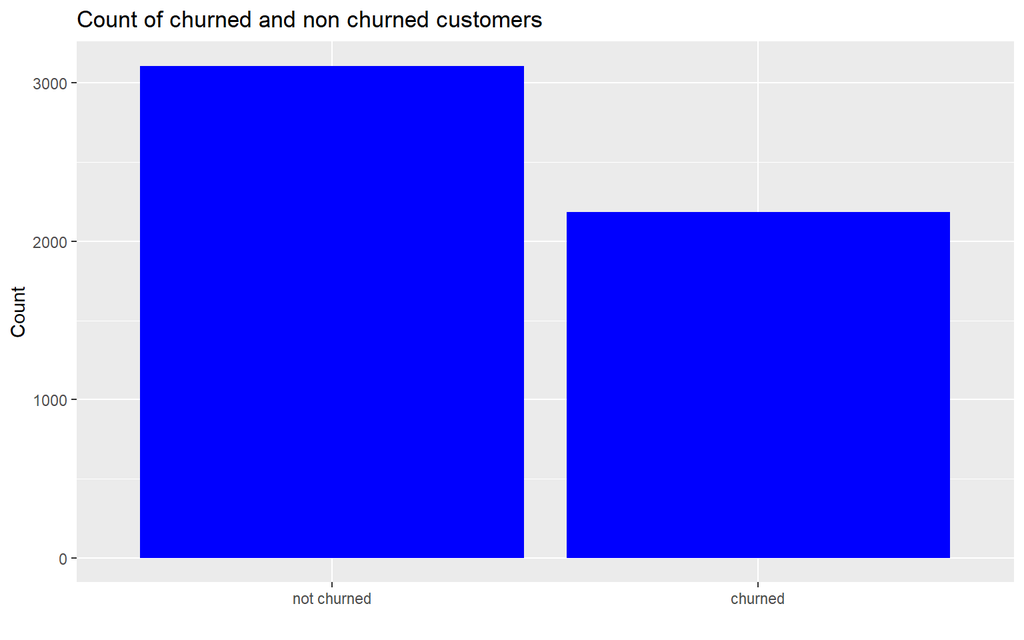

```r
# Reemplazar 0 y 1 en la columna 'is_churned' con etiquetas
df_reduction_copy$is_churned <- factor(df_reduction_copy$is_churned, levels = c(0, 1), labels = c("not churned", "churned"))

# Crear el gráfico de conteo
ggplot(data = df_reduction_copy, aes(x = is_churned)) +
  geom_bar(fill = "blue") +
  labs(title = "Count of churned and non churned customers",
       x = "",
       y = "Count")
```

# Descripción variables numericas vs is_churned

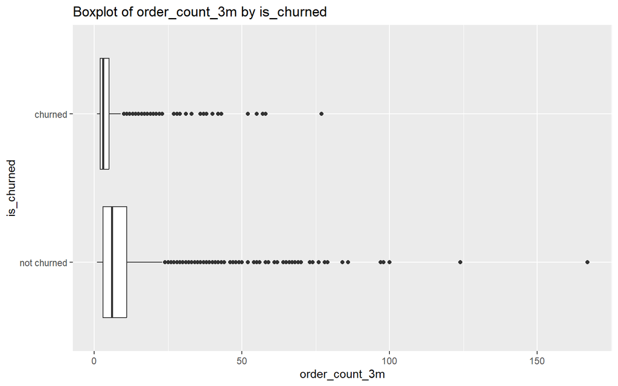

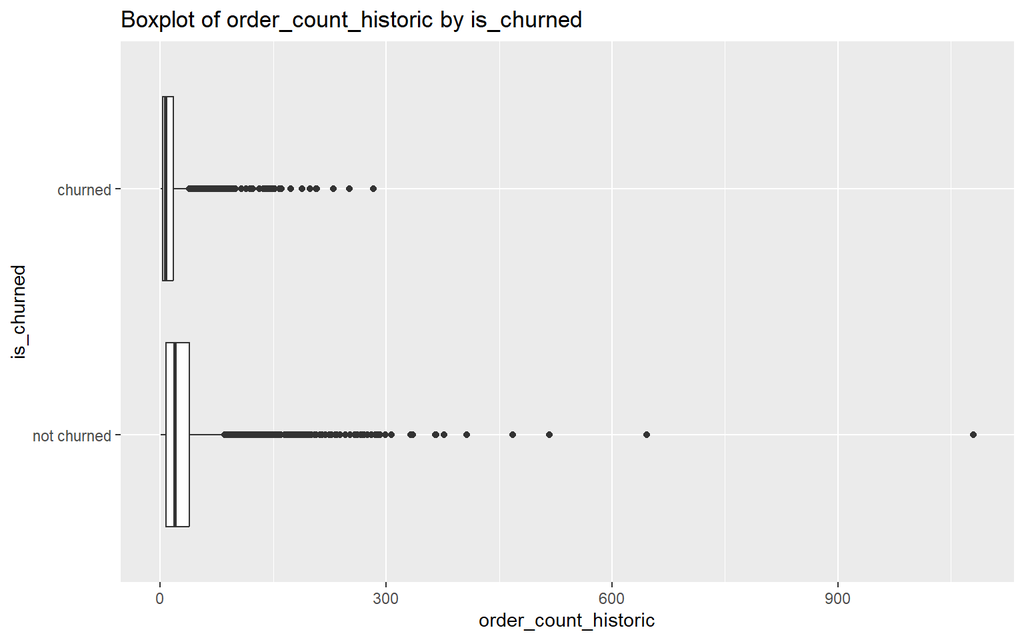

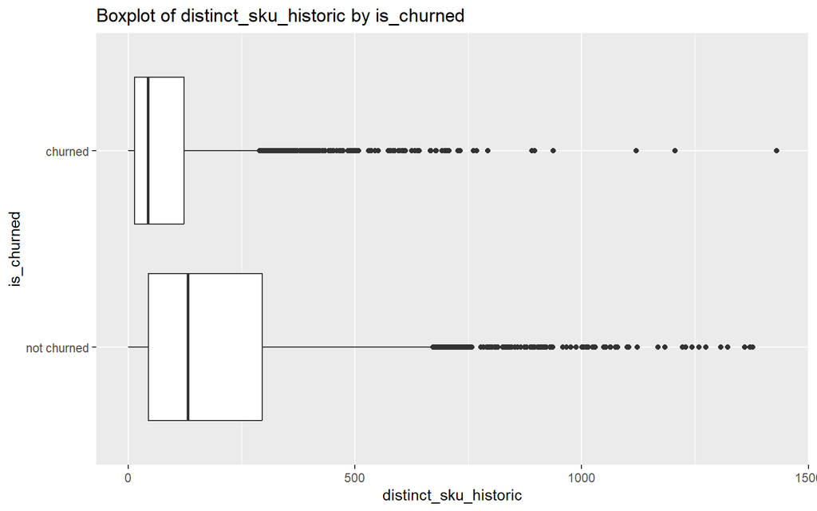

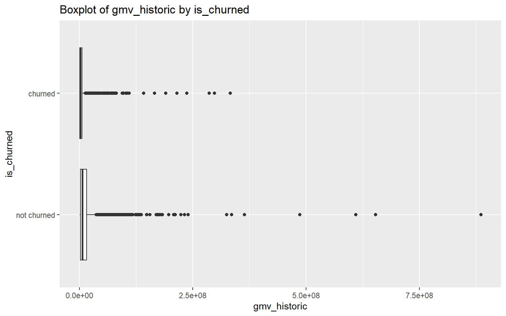

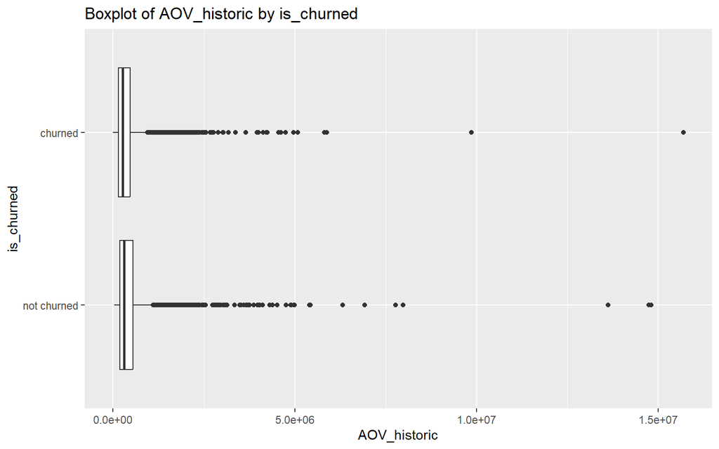

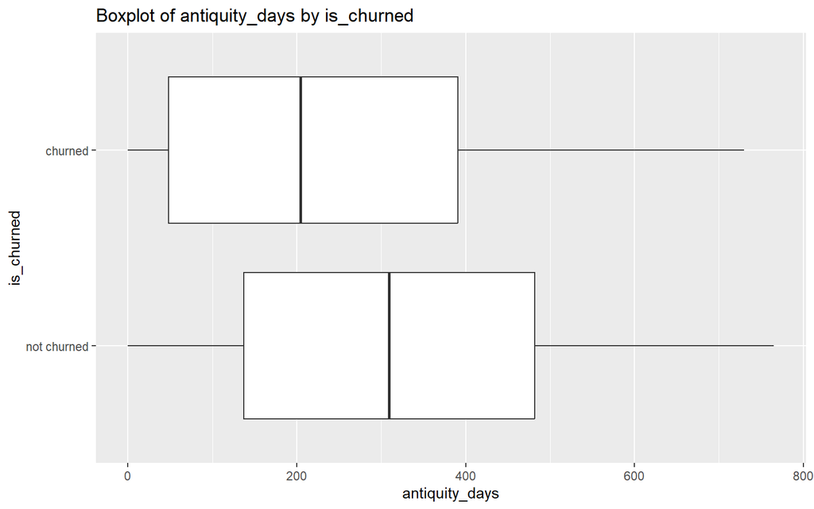

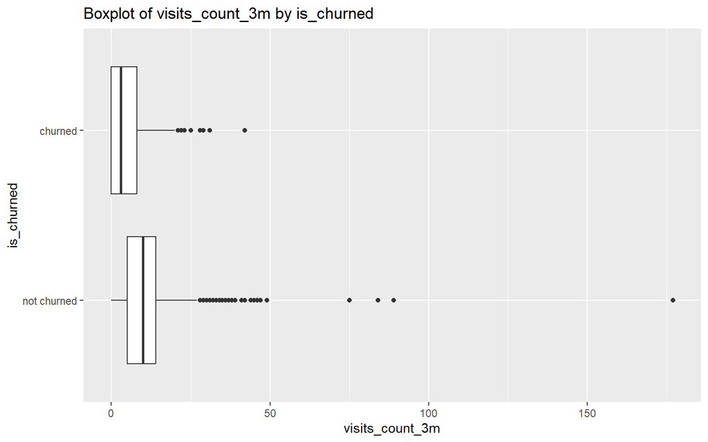

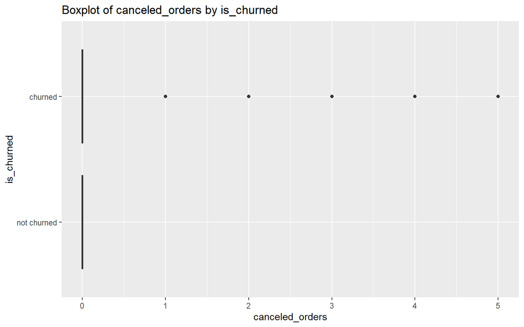

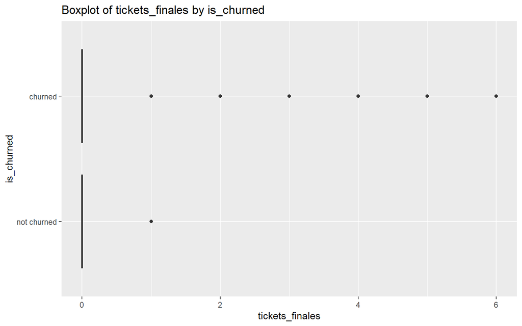

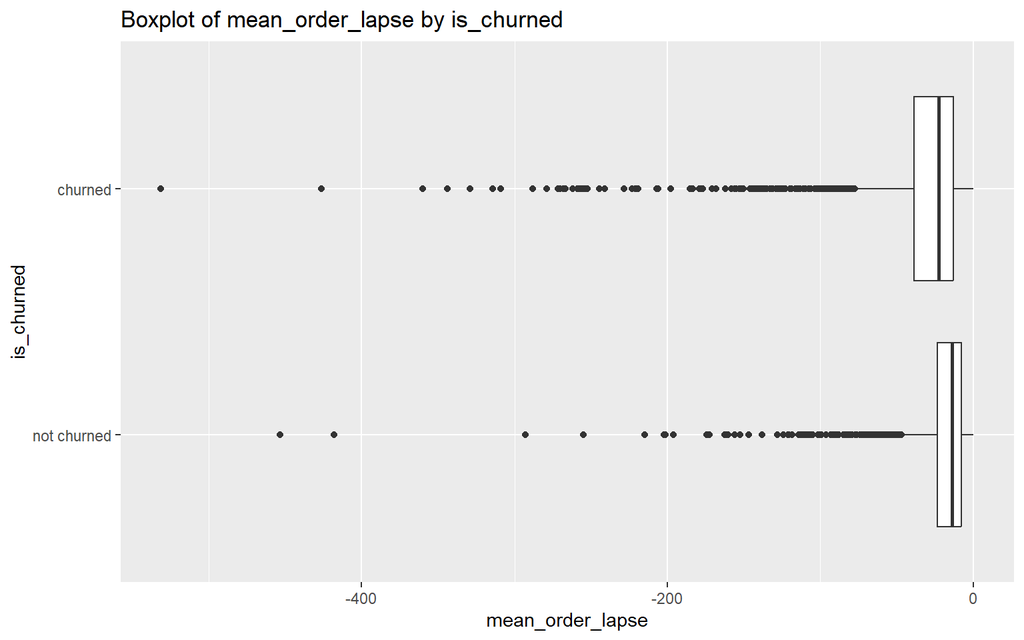

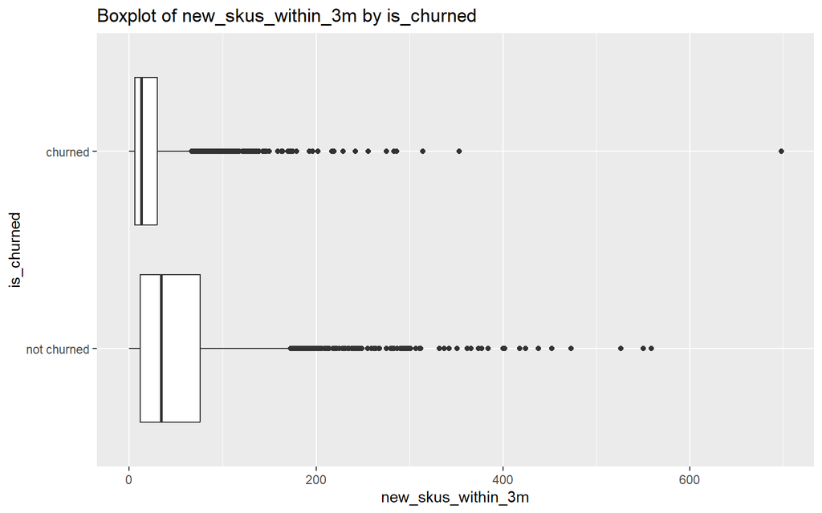

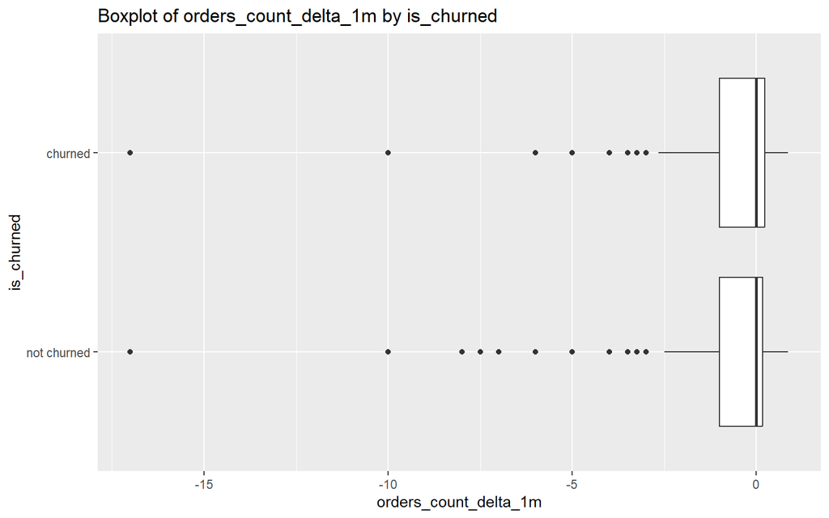

[5 more figures not shown]

```r
numerical_cols <- setdiff(names(df_reduction_copy), c('warehouse_Bogota', 'sub_categoria_Ambientadores', 'sub_categoria_Complementos.y.vitaminas', 'is_churned'))

# Crear un boxplot para cada columna numérica
for (col in numerical_cols) {
  p <- ggplot(df_reduction_copy, aes_string(x = "is_churned", y = col)) +
    geom_boxplot() +  # Elimina outliers
    coord_flip() +  # Hace el boxplot horizontal
    labs(title = paste("Boxplot of", col, "by is_churned"),
         y = col,
         x = "is_churned")
  print(p)
}
```

# variables categoricas vs is_churned

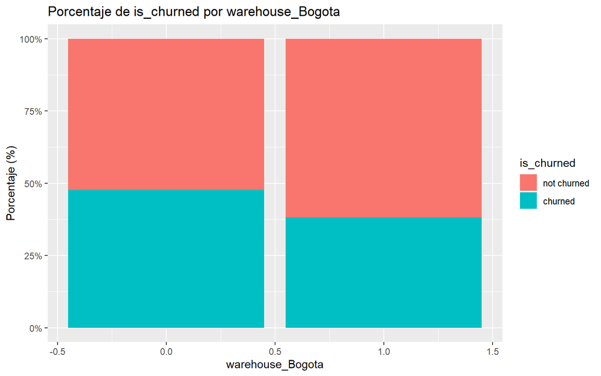

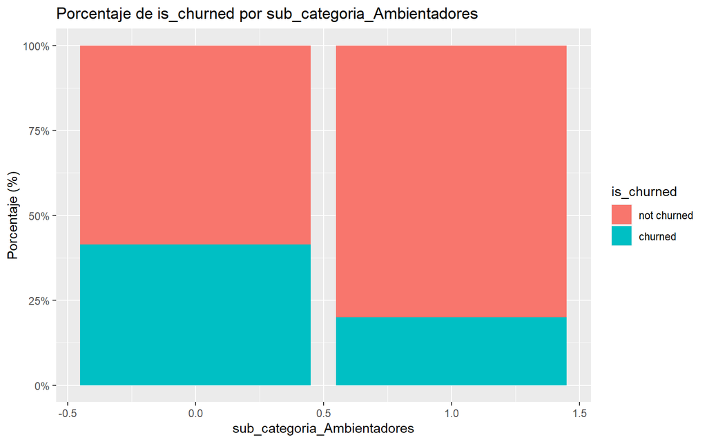

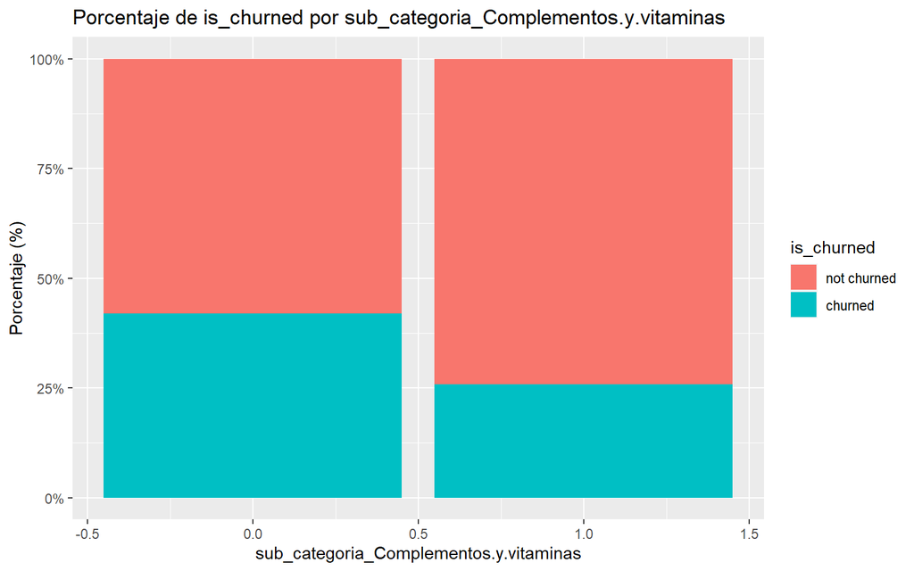

```r
df_categoricals_final <- df[, c(significant_columns, 'is_churned')]

df_categoricals_final$is_churned <- factor(df_categoricals_final$is_churned, levels = c(0, 1), labels = c("not churned", "churned"))

# Crear un gráfico de barras apiladas para cada variable categórica
for (col in significant_columns) {
  # Calcular los porcentajes
  df_percent <- df_categoricals_final %>%
    group_by_at(col) %>%
    count(is_churned) %>%
    group_by_at(col) %>%
    mutate(perc = n / sum(n) * 100)

  # Crear el gráfico
  p <- ggplot(df_percent, aes_string(x = col, y = "perc", fill = "is_churned")) +
    geom_bar(stat = "identity", position = "fill") +
    labs(title = paste("Porcentaje de is_churned por", col),
         x = col,
         y = "Porcentaje (%)") +
    scale_y_continuous(labels = scales::percent)

  print(p)
}
```

# Entrenando modelos de ML

## Train test split

se procede a hacer un train_test split con un 20% de datos como test

```r
names(df_final)
```

```
##  [1] "order_count_3m"
##  [2] "order_count_historic"
##  [3] "distinct_sku_historic"
##  [4] "gmv_historic"
##  [5] "AOV_historic"
##  [6] "antiquity_days"
##  [7] "visits_count_3m"
##  [8] "canceled_orders"
##  [9] "tickets_finales"
## [10] "mean_order_lapse"
## [11] "new_skus_within_3m"
## [12] "orders_count_delta_1m"
## [13] "gmv_delta_1m"
## [14] "distinct_skus_delta_1m"
## [15] "orders_count_delta_2m"
## [16] "gmv_delta_2m"
## [17] "distinct_skus_delta_2m"
## [18] "warehouse_Bogota"
## [19] "sub_categoria_Ambientadores"
## [20] "sub_categoria_Complementos.y.vitaminas"
## [21] "is_churned"
```

```r
library(caTools)
library(pROC)

df_final$warehouse_Bogota <- factor(df_final$warehouse_Bogota)
df_final$sub_categoria_Ambientadores <- factor(df_final$sub_categoria_Ambientadores)
df_final$sub_categoria_Complementos.y.vitaminas <- factor(df_final$sub_categoria_Complementos.y.vitaminas)
df_final$is_churned <- factor(df_final$is_churned)

set.seed(123)  # for reproducibility
split <- sample.split(df_final$is_churned, SplitRatio = 0.8)
train_set <- subset(df_final, split == TRUE)
test_set <- subset(df_final, split == FALSE)

# escalando los datos

# For train_set
numeric_columns <- sapply(train_set, is.numeric)
train_set[numeric_columns] <- scale(train_set[numeric_columns])

# For test_set
numeric_columns <- sapply(test_set, is.numeric)
test_set[numeric_columns] <- scale(test_set[numeric_columns])
```

```r
write.csv(test_set, "test_set.csv", row.names = FALSE)
```

```r
test <- read.csv("train_set.csv")
test$warehouse_Bogota <- factor(test$warehouse_Bogota)
test$sub_categoria_Ambientadores <- factor(test$sub_categoria_Ambientadores)
test$sub_categoria_Complementos.y.vitaminas <- factor(test$sub_categoria_Complementos.y.vitaminas)
test$is_churned <- factor(test$is_churned)
```

## Regresión Logística

```r
# Training a logistic regression model
model <- glm(is_churned ~ ., data = train_set, family = "binomial")

saveRDS(model, file = "logistic_regression.rds")

# Making predictions on the test set
predictions <- predict(model, newdata = test_set, type = "response")
predicted_class <- ifelse(predictions > 0.5, 1, 0)

# Creating a confusion matrix
confusion_matrix <- table(test_set$is_churned, predicted_class)

# Calculating precision, recall, and accuracy
precision <- confusion_matrix[2,2] / sum(confusion_matrix[,2])
recall <- confusion_matrix[2,2] / sum(confusion_matrix[2,])
accuracy <- sum(diag(confusion_matrix)) / sum(confusion_matrix)

# Calculating F1 score
f1_score <- 2 * (precision * recall) / (precision + recall)

# Printing metrics
print(paste("Precision:", precision))
```

```
## [1] "Precision: 0.654228855721393"
```

```r
print(paste("Recall:", recall))
```

```
## [1] "Recall: 0.601830663615561"
```

```r
print(paste("Accuracy:", accuracy))
```

```
## [1] "Accuracy: 0.704438149197356"
```

```r
print(paste("F1 Score:", f1_score))
```

```
## [1] "F1 Score: 0.626936829558999"
```

```r
# Calculating AUC
roc_curve <- roc(response = test_set$is_churned, predictor = predictions)
auc_value <- auc(roc_curve)

# Printing AUC
print(paste("AUC:", auc_value))
```

```
## [1] "AUC: 0.78563282244476"
```

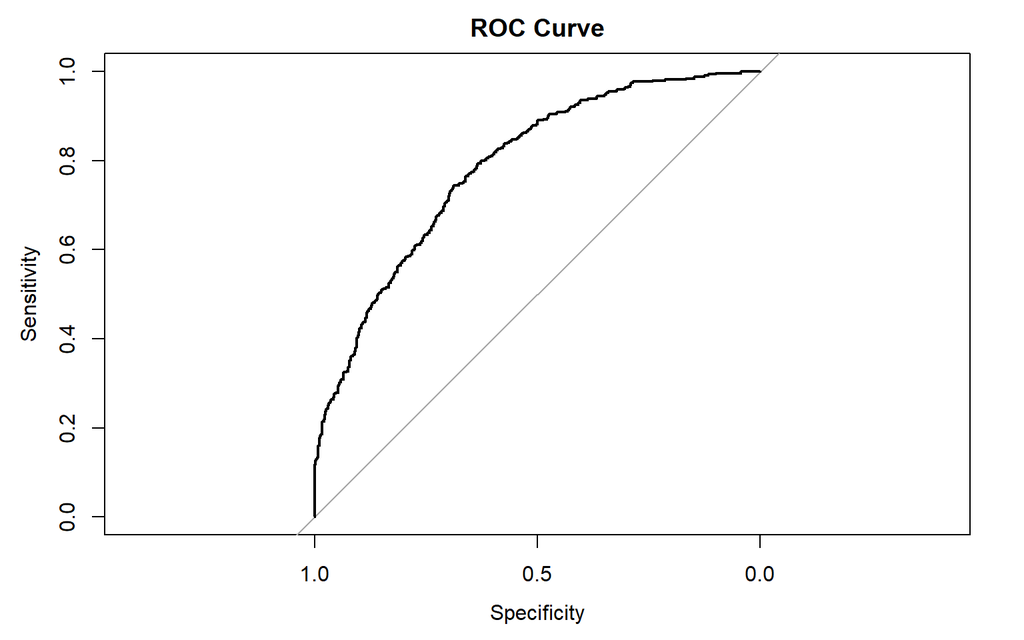

```r
# Plotting the ROC curve
plot(roc_curve, main = "ROC Curve")
```

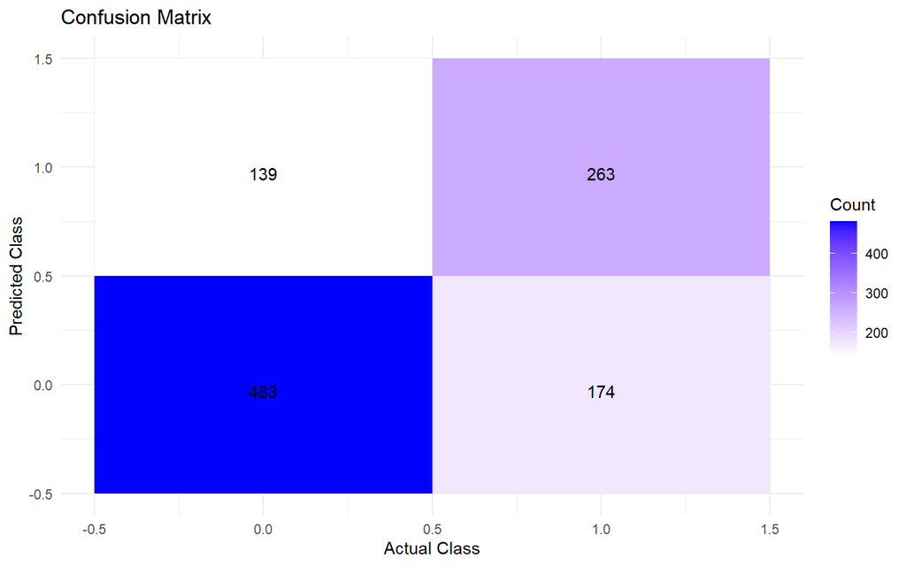

```r
confusion_df <- as.data.frame(melt(confusion_matrix))

# Rename columns for clarity
colnames(confusion_df) <- c("Reference", "Prediction", "Count")

# Plot using ggplot2
ggplot(confusion_df, aes(x = Reference, y = Prediction, fill = Count)) +
  geom_tile() +
  geom_text(aes(label = Count), vjust = 1) +
  scale_fill_gradient(low = "white", high = "blue") +
  theme_minimal() +
  labs(title = "Confusion Matrix", x = "Actual Class", y = "Predicted Class", fill = "Count")
```

## random forest

```r
# Ensure the randomForest package is installed and loaded
library(randomForest)

# Training a Random Forest model
model <- randomForest(is_churned ~ ., data = train_set)

# Save the model
saveRDS(model, file = "random_forest_model.rds")

# Making predictions on the test set
predictions_prob <- predict(model, newdata = test_set, type = 'prob')

prob_positive_class <- predictions_prob[, "1"]
predicted_class <- ifelse(prob_positive_class > 0.5, 1, 0)

# Creating a confusion matrix
confusion_matrix <- table(test_set$is_churned, predicted_class)

# Calculating precision, recall, and accuracy
precision <- confusion_matrix[2,2] / sum(confusion_matrix[,2])
recall <- confusion_matrix[2,2] / sum(confusion_matrix[2,])
accuracy <- sum(diag(confusion_matrix)) / sum(confusion_matrix)

# Calculating F1 score
f1_score <- 2 * (precision * recall) / (precision + recall)

# Printing metrics
print(paste("Precision:", precision))
```

```
## [1] "Precision: 0.621376811594203"
```

```r
print(paste("Recall:", recall))
```

```
## [1] "Recall: 0.784897025171625"
```

```r
print(paste("Accuracy:", accuracy))
```

```
## [1] "Accuracy: 0.713881019830028"
```

```r
print(paste("F1 Score:", f1_score))
```

```
## [1] "F1 Score: 0.693629929221436"
```

```r
# Calculating and printing AUC
roc_curve <- roc(response = test_set$is_churned, predictor = prob_positive_class)
auc_value <- auc(roc_curve)
print(paste("AUC:", auc_value))
```

```
## [1] "AUC: 0.783475096941291"
```

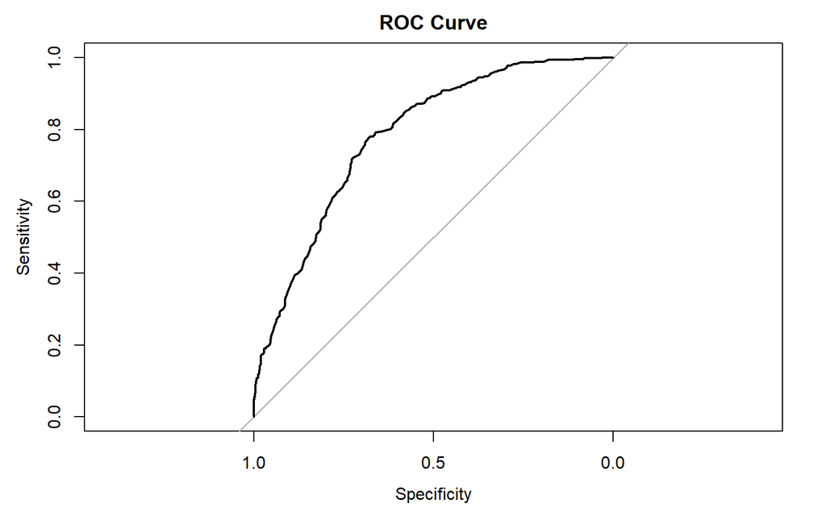

```r
# Plotting the ROC curve
plot(roc_curve, main = "ROC Curve")
```

## XGBoost

```r
# Ensure the xgboost package is installed and loaded
library(xgboost)

# Convert factors to numeric
num_conversion <- function(df) {
  for (col in names(df)) {
    if (is.factor(df[[col]])) {
      df[[col]] <- as.numeric(as.character(df[[col]]))
    }
  }
  return(df)
}

train_set_num <- num_conversion(train_set)
test_set_num <- num_conversion(test_set)

# Now convert to matrix
train_data <- as.matrix(train_set_num[, -which(names(train_set_num) == "is_churned")])
train_label <- train_set_num$is_churned

test_data <- as.matrix(test_set_num[, -which(names(test_set_num) == "is_churned")])
test_label <- test_set_num$is_churned

# Proceed with XGBoost training as before
dtrain <- xgb.DMatrix(data = train_data, label = train_label)
dtest <- xgb.DMatrix(data = test_data, label = test_label)

# Parameters for XGBoost
params <- list(
  objective = "binary:logistic",
  eval_metric = "logloss"
)

# Training XGBoost model
model <- xgboost(params = params, data = dtrain, nrounds = 100)
# Save the model
saveRDS(model, file = "xgboost_model.rds")

# Making predictions on the test set
predictions <- predict(model, dtest)
predicted_class <- ifelse(predictions > 0.5, 1, 0)

# Creating a confusion matrix
confusion_matrix <- table(test_label, predicted_class)

# Calculating precision, recall, and accuracy
precision <- confusion_matrix[2,2] / sum(confusion_matrix[,2])
recall <- confusion_matrix[2,2] / sum(confusion_matrix[2,])
accuracy <- sum(diag(confusion_matrix)) / sum(confusion_matrix)

# Calculating F1 score
f1_score <- 2 * (precision * recall) / (precision + recall)

# Printing metrics
print(paste("Precision:", precision))
```

```
## [1] "Precision: 0.598591549295775"
```

```r
print(paste("Recall:", recall))
```

```
## [1] "Recall: 0.778032036613272"
```

```r
print(paste("Accuracy:", accuracy))
```

```
## [1] "Accuracy: 0.693106704438149"
```

```r
print(paste("F1 Score:", f1_score))
```

```
## [1] "F1 Score: 0.676616915422886"
```

```r
# Calculating AUC
roc_curve <- roc(response = test_label, predictor = predictions)
auc_value <- auc(roc_curve)
print(paste("AUC:", auc_value))
```

```
## [1] "AUC: 0.771089789341241"
```

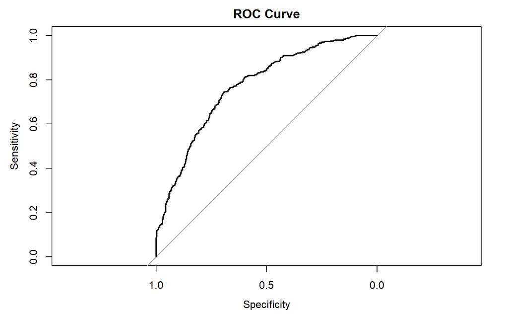

```r
# Plotting the ROC curve
plot(roc_curve, main = "ROC Curve")
```

## loading the models for testing

### testing logreg file

```r
logreg <- readRDS(file = "logistic_regression.rds")

# Making predictions on the test set
predictions <- predict(logreg, newdata = test_set, type = "response")
predicted_class <- ifelse(predictions > 0.5, 1, 0)

# Creating a confusion matrix
confusion_matrix <- table(test_set$is_churned, predicted_class)

# Calculating precision, recall, and accuracy
precision <- confusion_matrix[2,2] / sum(confusion_matrix[,2])
recall <- confusion_matrix[2,2] / sum(confusion_matrix[2,])
accuracy <- sum(diag(confusion_matrix)) / sum(confusion_matrix)

# Calculating F1 score
f1_score <- 2 * (precision * recall) / (precision + recall)

# Printing metrics
print(paste("Precision:", precision))
```

```
## [1] "Precision: 0.654228855721393"
```

```r
print(paste("Recall:", recall))
```

```
## [1] "Recall: 0.601830663615561"
```

```r
print(paste("Accuracy:", accuracy))
```

```
## [1] "Accuracy: 0.704438149197356"
```

```r
print(paste("F1 Score:", f1_score))
```

```
## [1] "F1 Score: 0.626936829558999"
```

```r
# Calculating AUC
roc_curve <- roc(response = test_set$is_churned, predictor = predictions)
auc_value <- auc(roc_curve)

# Printing AUC
print(paste("AUC:", auc_value))
```

```
## [1] "AUC: 0.78563282244476"
```

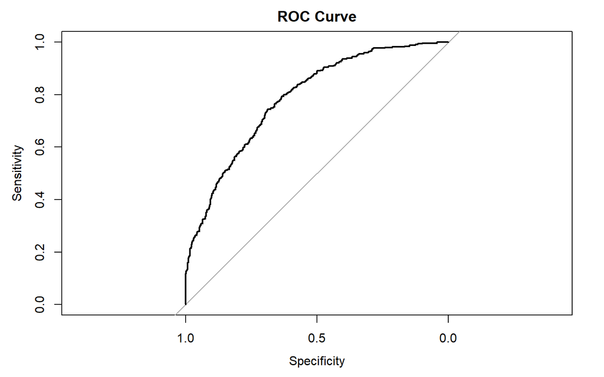

```r
# Plotting the ROC curve
plot(roc_curve, main = "ROC Curve")
```

### testing random forest file

```r
rand_forest <- readRDS(file = "random_forest_model.rds")

# Making predictions on the test set
predictions_prob <- predict(rand_forest, newdata = test_set, type = 'prob')

prob_positive_class <- predictions_prob[, "1"]
predicted_class <- ifelse(prob_positive_class > 0.5, 1, 0)

# Creating a confusion matrix
confusion_matrix <- table(test_set$is_churned, predicted_class)

# Calculating precision, recall, and accuracy
precision <- confusion_matrix[2,2] / sum(confusion_matrix[,2])
recall <- confusion_matrix[2,2] / sum(confusion_matrix[2,])
accuracy <- sum(diag(confusion_matrix)) / sum(confusion_matrix)

# Calculating F1 score
f1_score <- 2 * (precision * recall) / (precision + recall)

# Printing metrics
print(paste("Precision:", precision))
```

```
## [1] "Precision: 0.621376811594203"
```

```r
print(paste("Recall:", recall))
```

```
## [1] "Recall: 0.784897025171625"
```

```r
print(paste("Accuracy:", accuracy))
```

```
## [1] "Accuracy: 0.713881019830028"
```

```r
print(paste("F1 Score:", f1_score))
```

```
## [1] "F1 Score: 0.693629929221436"
```

```r
# Calculating and printing AUC
roc_curve <- roc(response = test_set$is_churned, predictor = prob_positive_class)
auc_value <- auc(roc_curve)
print(paste("AUC:", auc_value))
```

```
## [1] "AUC: 0.783475096941291"
```

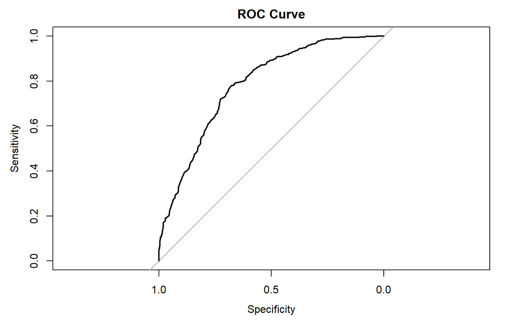

```r
# Plotting the ROC curve
plot(roc_curve, main = "ROC Curve")
```

### testing XGBoost file

```r
xgboost_model <- readRDS(file = "xgboost_model.rds")

# Making predictions on the test set
predictions <- predict(xgboost_model, dtest)
predicted_class <- ifelse(predictions > 0.5, 1, 0)

# Creating a confusion matrix
confusion_matrix <- table(test_label, predicted_class)

# Calculating precision, recall, and accuracy
precision <- confusion_matrix[2,2] / sum(confusion_matrix[,2])
recall <- confusion_matrix[2,2] / sum(confusion_matrix[2,])
accuracy <- sum(diag(confusion_matrix)) / sum(confusion_matrix)

# Calculating F1 score
f1_score <- 2 * (precision * recall) / (precision + recall)

# Printing metrics
print(paste("Precision:", precision))
```

```
## [1] "Precision: 0.598591549295775"
```

```r
print(paste("Recall:", recall))
```

```
## [1] "Recall: 0.778032036613272"
```

```r
print(paste("Accuracy:", accuracy))
```

```
## [1] "Accuracy: 0.693106704438149"
```

```r
print(paste("F1 Score:", f1_score))
```

```
## [1] "F1 Score: 0.676616915422886"
```

```r
# Calculating AUC
roc_curve <- roc(response = test_label, predictor = predictions)
auc_value <- auc(roc_curve)
print(paste("AUC:", auc_value))
```

```
## [1] "AUC: 0.771089789341241"
```

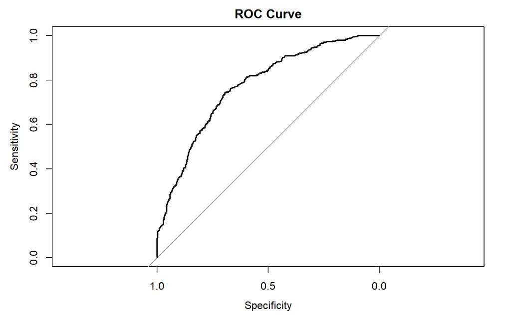

```r
# Plotting the ROC curve
plot(roc_curve, main = "ROC Curve")
```